# Part 1: Using R as a Research Tool

Dr Susan Johnston Susan.Johnston@ed.ac.uk

13th Feb 2024

## Introduction

This tutorial is based on information from [Our Coding Club](https://ourcodingclub.github.io/) and [R4all](http://r4all.org/). The datasets for this tutorial can be downloaded from https://github.com/susjoh/E4StatsTutorials

### What is **R**?

**R** began its life in New Zealand in 1993 as a language and environment for statistical computing and graphics. It is an interpreted programming language, meaning that rather than pointing and clicking, the user types in commands. It is **free** and works across all platforms.

### Why use **R**?

> “This is R. There is no if. Only how.”  
> – Simon ‘Yoda’ Blomberg, R-help (April 2005)

Almost anything is possible in **R**. It is fast becoming the *lingua franca* of academic research, statistics and data science. It is used for:

- Processing and tidying data
- Statistical analyses
- Data visualistion (`ggplot`)
- Creating interactive web applications (`shiny`)
- Generating reports and presentations (`knitr`, `slidify`)
- Creating portable projects (**RStudio** Projects)

The analytical power of **R** lies in its many packages (20,406 as of 12th Feb 2024). Hundreds of these are written for geoscience, ecology, evolutionary biology, chemistry, etc.. A list of packages are hosted on the Comprehensive R Archive Network (known as **CRAN**): https://cran.r-project.org/

## Getting Started: **R** and **RStudio**.

### Installing **R** and **RStudio**

**R** can be downloaded from the CRAN website. Whilst the CRAN download version provides a simple user interface, we recommend that **R** is run through the software **RStudio** This is open-source, free, and available [here](http://www.rstudio.com/).

### Creating an **R** Project.

Using **R** Projects (`.RProj`) allows easier file imports, improved reproducibility and collaboration. This is because it tells **R** where to look for data files and scripts, meaning that a script can be run different machines and environments without any problems. Projects can be created using `File > New Project` and following the instructions.

We have provided the project `Intro_to_R.RProj`. Opening this file will open **RStudio**. If you would rather not use projects, you can set the working directory by using the command `setwd()` or by selecting `Session > Set working directory > Choose directory`

On the Files tab in the **lower right**, you will see the files in the current working directory. This will be useful later when we tell **R** to load files. You can check the working directory by typing `getwd()`.

### Structuring an **R** Project.

Using a good project layout keeps the data reliable, portable and reproducible. This makes it easier for you or a collaborator to pick up the project after a break. There is no single way to structure a project, but an suggestion is shown in Figure 1. This is based on a blog post on Nice R Code available [here](https://nicercode.github.io/blog/2013-04-05-projects/).

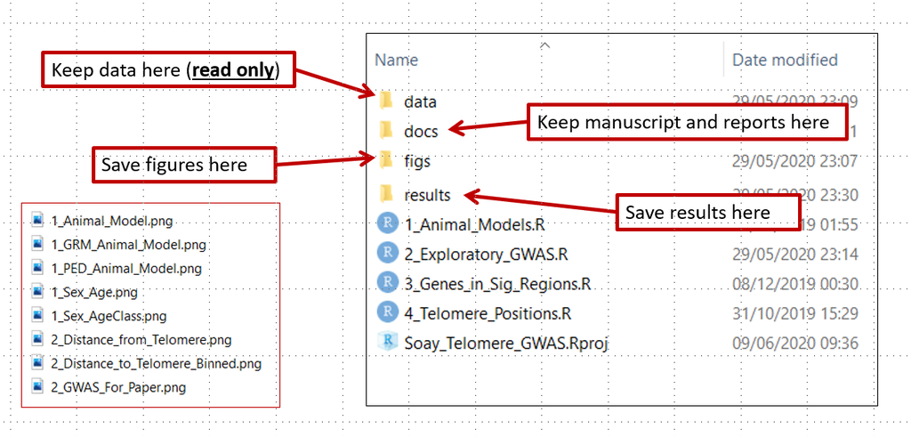

*Figure 1: Example structure for a portable R project.*

- `data` contains all data used in the analysis and should be treated as **read only** - these files should never be edited or overwritten. Rather, they should be processed within R scripts.
- `docs` contains the paper and/or reports associated with the analysis (in Word, R Markdown, LaTeX, etc).
- `figs` contains any figures generated by R scripts.
- `results` contains any simulation outputs, processed data etc. NB. Data in `figs` and `results` can be treated as disposable.
- `[filename].R` are R scripts. You can split your workflow into units that are logical for you, such as (a) load, merge and clean data, (b) analyse the data and (c) create outputs such as results tables and figures. Some researchers use a numbering method so that the order in which to run different scripts is clear.
- `[filename].Rproj` is the portable R project.

** The take-home message is to start your analysis from copies of the raw data, doing any cleaning, transforming, merging and so on in scripts. Always comment and document your code thoroughly, explain what it is doing and why.**

### Using **RStudio**

Open `Intro_to_R.RProj` and create a new **R** Script (`File > New File > R Script`). **RStudio** should look like Figure 2.

[figure not shown]

*Figure 2. The RStudio Environment. Adapted from OurCodingClub.github.io*

On the **lower left** is the **Console** pane - this is the engine of **R**. You can give instructions to **R** by directly typing at the prompt (`>`).

On the **upper left** is your **R** Script - here, you can write commands and send them to the console by clicking `Run` or by typing `Ctrl-Enter`. `#` is the comment character in **R**.

On the **lower right**, you can browse the packages installed on your machine, open files and search **R** Help. This pane will also show plots when we run them later in the practical.

### **Exercise 1**

Try running some basic commands directly in the console and from the **R** Script:

```r
2+3
1:10
seq(from = 1, to = 20, by = 4)
mean(c(3, 6, 9, 3, 6, 7))
```

Let’s assign a sequence of numbers to an object, `x`:

```r
x <- 1:10
x
y <- seq(from = 0, to = 4.5, by = 0.5)
y
```

You can see that in the upper right pane, we can see this new objects `x` and `y` in the environment.

**Click here for advanced exercises**

Read the next short paragraph on finding help within R. Use this information to generate two vectors of length 100.

`x` is normally distributed with a mean of 0 and a standard deviation of 1.

`y` is uniformly distributed with a range between 0 & 1.

### Finding Help within **R**.

The fastest way to find help in **R** is to search using `?`. For example:

```r
?mean
```

should bring up a help page for the function `mean()` in the lower right corner. Typing two question marks will search all help files and return a list of those that match.

```r
??mean
??"standard error"
```

### **Exercise 2.**

1. Using only `?` and/or `??`, find a function for calculating the standard deviation. What is the standard deviation of `x`?
2. Using `?`, find the help file for the `sort()` function. Sort `x` and `y` in reverse order.

### Troubleshooting and finding help outside of **R**.

- [Coding Club Tutorials & Useful Links](https://ourcodingclub.github.io/)
- [Stack Overflow](https://stackoverflow.com/): Try searching with the tag [R]
- [**RStudio** Cheatsheets](https://www.rstudio.com/resources/cheatsheets/)

## The Tidyverse.

[figure not shown]

In these practicals, we are going to use a suite of packages known as the `tidyverse`. These can be installed by running the following:

```
install.packages(tidyverse)
```

This installs the library from CRAN. It may ask you to select a mirror - select the one that which is geographically closest, or the RStudio Global mirror.

Then each time we use R, we need to load the `tidyverse` package. It is good practice to do this at the beginning of the script when you are setting up the working environment.

```r
library(tidyverse)
```

There are three sub-packages within the tidyverse that are used within this practical:

- `readr` - this is a fast way to read in “rectangular” data (e.g. tables).
- `dplyr` - a packages for common data manipulation tasks.
- `ggplot2` - the industry standard for data visualisation.

## Loading data into **R**.

Now that we are familiar with the **RStudio** environment, it’s time to start working with real data. In the folder `data`, you have been provided with a single dataset on Peruvian Soil in two common formats - `.txt` (tab-delimited) and `.csv` (comma-delimited).

Using **R** Projects means that the working directory is the same as the .Rproj file. We will use `read_delim()` to read in the data-set. Try typing the following into your script, and guiding the command to the `.csv` version of the data file using the `Tab` key:

```r
Peru_Soil_Data <- read_delim("
```

You should now have the following code in your script:

```r
Peru_Soil_Data <- read_delim("data/Peru_Soil_Data.csv")
```

You can also use the base R function `read.table()` which offers more flexibility on defining various features about the input files.

### Exercise 3.

- Read the file `Peru_Soil_Data.txt` into **R**. Check the loaded object using the `head()` function. Do you need additional arguments to read in the file properly?
- The object `Peru_Soil_Data` is a type of object known as a **data frame**. You should ALWAYS check the data visually by clicking on its entry in the Environment tab, and/or using functions in base **R** for exploring data e.g. `head()` and `str()` and `glimpse()`. Try these out.

**Click here for advanced exercises**

Read in `data/Peru_Soil_Data.txt` with `read.table()`. If it doesn’t work, check the help file. If it does work, has all the data read in properly?

Read in `docs/Peru_Soil_Data_Problematic.txt` with `read.table()`. If it doesn’t work, check the help file. If it does work, has all the data read in properly?

## Data management in **R**.

Exploring and manipulating data is fundamental to data analysis. In this section, we will briefly cover how to sort and filter the soil dataset. There are several approaches to doing this in the base code of **R**, but here we will use on the functions `select()`, `filter()` and `arrange()` from the tidyverse package `dplyr`.

### Sorting data with `arrange()`

There are occasions where it is useful to have sorted data, either because we would like to examine it, or for some types of statistical analyses i.e. with time-series data. The `arrange()` function sorts data frames as so:

```r
# sort by Soil pH value:
arrange(Peru_Soil_Data, Soil_pH)
# sort by decreasing Soil pH value:
arrange(Peru_Soil_Data, -Soil_pH)
# sort by habitat and then soil pH within habitat:
arrange(Peru_Soil_Data, Habitat, Soil_pH)
```

These can be saved back to the `Peru_Soil_Data` object like so:

```r
Peru_Soil_Data <- arrange(Peru_Soil_Data, Habitat, Soil_pH)
```

### Sub-setting columns with `select()`

At its simplest, columns can be selected using their numeric references in square brackets (**after** the comma):

```r
Peru_Soil_Data[,1]
Peru_Soil_Data[,3:5]
Peru_Soil_Data[,c(1, 4, 5)]
Peru_Soil_Data[,c("Habitat", "Phosphorus")]
```

It is not recommended to use numerical references, as addition or removal of columns can lead to mistakes. The best solution is to use the column names themselves. A convenient way to do this is to use the `dplyr` `select()` function, which will select or remove columns of the data. Try running:

```r
select(Peru_Soil_Data, River_Basin)
select(Peru_Soil_Data, -River_Basin)
```

More than one column can be selected or removed by adding more column names:

```r
select(Peru_Soil_Data, River_Basin, Magnesium, Sodium)
select(Peru_Soil_Data, -River_Basin, -Magnesium, -Sodium)
```

### Adding columns.

New columns can be added to the data containing information or calculations that you are interested in. We can do this in standard base **R** using the code `$`, which can be used to call existing variables from a data frame. For example, river basin can be called as so:

```r
Peru_Soil_Data$River_Basin
```

Columns can be added by creating new variables within the data frame. Here, we can create a new column called `log_Calcium` which takes the `log_{10}` of the Calcium column:

```r
Peru_Soil_Data$log_Calcium <- log10(Peru_Soil_Data$Calcium)

head(select(Peru_Soil_Data, Site, Calcium, log_Calcium))
```

### Sub-setting rows with `filter()`

Sub-setting data by rows is one of the most common tasks carried out in data manipulation steps. Again, at it’s simplest, rows can be selected using their numeric references in square brackets (**before** the comma):

```r
Peru_Soil_Data[1,]
Peru_Soil_Data[1:5,]
```

However, this is clearly not useful if we wish to select rows based on a particular criteria. For this, we can used the `filter()` function, specifying an argument with the following logical operators:

| Operator | Function |
| --- | --- |
| `<` | less than |
| `>` | greater than |
| `=<` | less than or equal to |
| `=>` | greater than or equal to |
| `==` | equals |
| `!=` | does not equal |
| `%in%` | matches |

### **Exercise 4.**

1. Create a new data frame, `Peru_Upland_Soil`, which includes row only from upland habitats.
2. Edit this data frame so that it only includes data from the Manu and Los Amigos river basins (Hint: use `%in%`)
3. Edit this data frame again so that it is sorted by increasing Calcium levels.
4. Create a new column called `Sum_Ca_Mg` that is the sum of the calcium and magnesium columns.

**Click here for advanced exercises**

5. Explore the `group_by()` and `summarise()` function in `dplyr` using `?` or a search engine. Use these functions to create a data frame with the mean Phosphorus and Calcium measures for each habitat.
6. There was a problem with the device measuring the Calcium concentrations in Los Amigos. Can you multiply *only* these data points by two within the data frame??

## Data visualisation with `ggplot2`

Data visualisation is the visual representation of data in the form of plots, charts, maps and infographics. It is an accessible way to identify patterns and trends in your data, but can also tell you about the quality of your data and how it should be analysed.

Data visualisation is an important part of our every day lives e.g such as on the BBC News (who use R to produce their graphics - see [here](https://bbc.github.io/rcookbook/) on how they do it!)

One of **R**’s most powerful tools is its ability to produce publication quality graphics in an automated and reproducible way.

#### The first step of any analysis: PLOT YOUR DATA!

A good illustration of why this is important is using a dataset called the Anscombe’s Quartet:

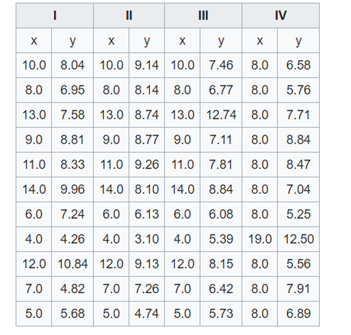

Each of these 4 data sets has an almost identical results for linear regression (R2, slope and intercept):

```r
summary(lm(anscombe$y1 ~ anscombe$x1))
```

```
##
## Call:
## lm(formula = anscombe$y1 ~ anscombe$x1)
##
## Residuals:
##      Min       1Q   Median       3Q      Max
## -1.92127 -0.45577 -0.04136  0.70941  1.83882
##
## Coefficients:
##             Estimate Std. Error t value Pr(>|t|)
## (Intercept)   3.0001     1.1247   2.667  0.02573 *
## anscombe$x1   0.5001     0.1179   4.241  0.00217 **
## ---
## Signif. codes:  0 '***' 0.001 '**' 0.01 '*' 0.05 '.' 0.1 ' ' 1
##
## Residual standard error: 1.237 on 9 degrees of freedom
## Multiple R-squared:  0.6665, Adjusted R-squared:  0.6295
## F-statistic: 17.99 on 1 and 9 DF,  p-value: 0.00217
```

However, plotting these figures shows a different picture (literally and metaphorically):

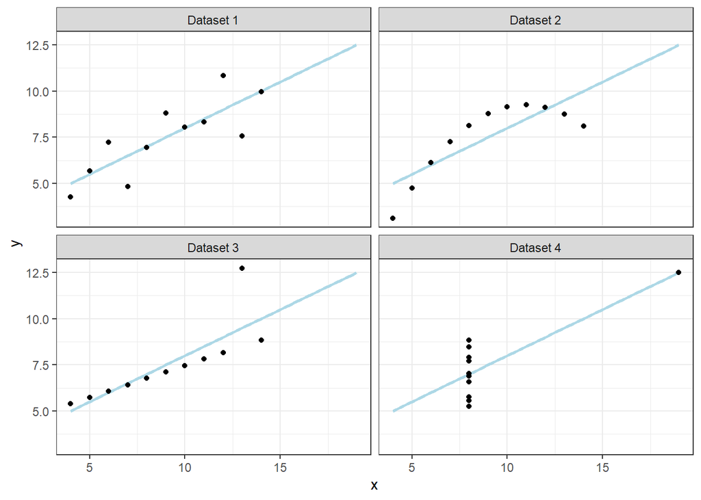

```r
anscombe_plot
```

How would you change your data analysis based on the patterns that you visualise?

## Simple graphics in R (base graphics)

One of **R**’s most powerful tools is its ability to produce publication quality graphics in an automated and reproducible way.

Base **R** contains graphical tools for simple, exploratory graphics. These are easily called with functions such as `hist()` and `plot()`:

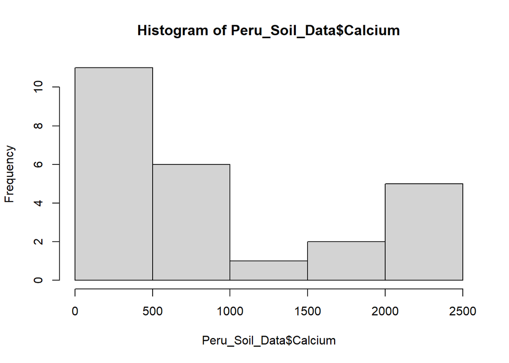

```r
# histogram
hist(Peru_Soil_Data$Calcium)
```

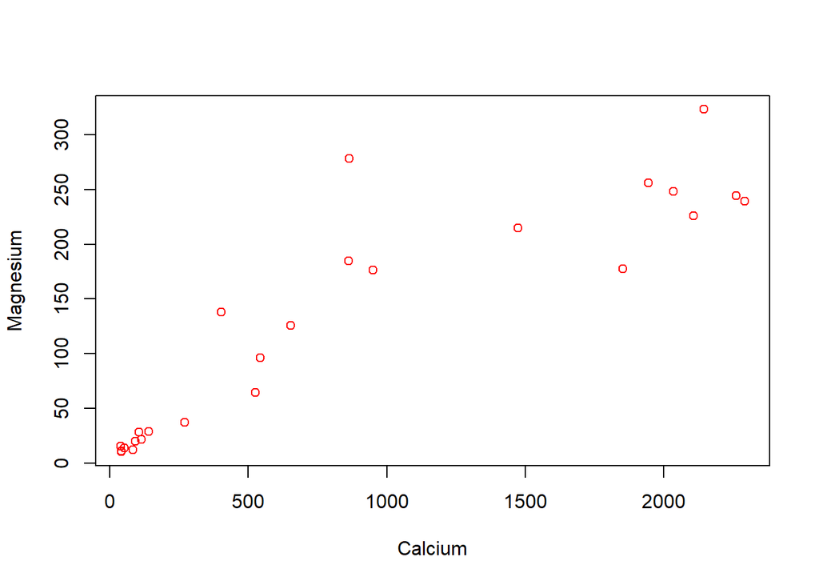

```r
# plot
plot(Magnesium ~ Calcium, data = Peru_Soil_Data, col = "red")
```

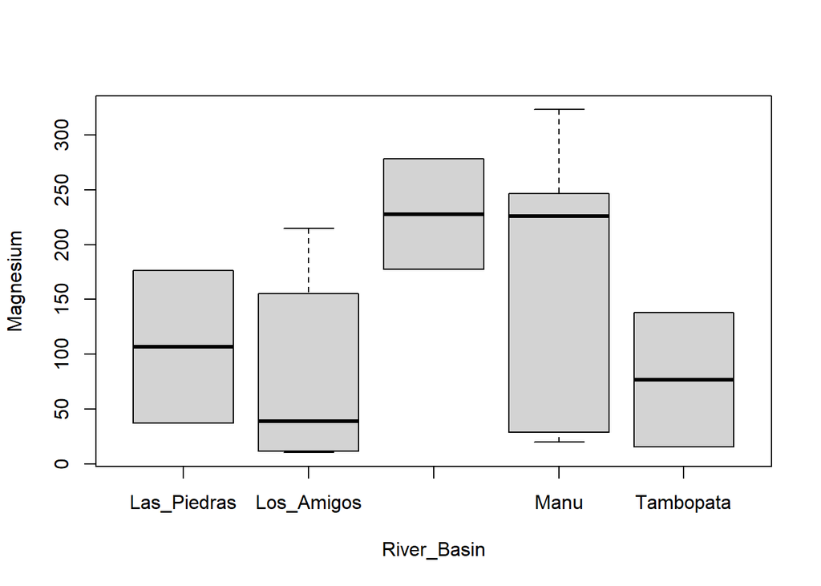

```r
# boxplot
boxplot(Magnesium ~ River_Basin, data = Peru_Soil_Data)
```

You can do many things you require in base graphics, but common actions and customisation are difficult. Base graphics are good for quick data exploration, but for everything else we recommend the graphics library `ggplot2`. If you want to explore customisation of base graphics, you can access my tutorial [here](https://rstudio-pubs-static.s3.amazonaws.com/7953_4e3efd5b9415444ca065b1167862c349.html).

## `ggplot2` - the grammar of graphics.

`ggplot2` is a plotting system in **R** which aims to take the best parts of base graphics and allow for easy plot customisation. It has extensive documentation and examples [here](https://ggplot2.tidyverse.org/reference/index.html)

The beauty of `ggplot2` is that you can build up the graph in different steps. The main steps can be summarised as follows:

1. **Data:** `ggplot()` Data with aesthetic (visual) properties (`aes()`).
2. **Geom:** `geom_...()` The type of plot (line, point, box-plot, etc.)
3. **Stat:** `stat_...()` Statistical transformations (regression lines, smoothers, etc)*
4. **Theme** `theme() and others` How do you want your graph to look? 5+ **Other customisations** e.g. facetings, scales, zoom, etc.
- NB. every geom has a default statistic, so this component is not always specified.